# Survey data summary

EWilliams

2026-08-06

# Data checks

**FIXED STATIONS**  
Summary information:

| Estuary | Start | End |
| --- | --- | --- |
| AB | 2015 | 2024 |
| BB | 2005 | 2007 |
| CR | 2017 | 2025 |
| LW | 2005 | 2025 |
| LX | 2005 | 2025 |
| ML | 2005 | 2007 |
| SL | 2005 | 2025 |
| SR | 2005 | 2007 |
| TB | 2005 | 2025 |

| Quarter | 2005 | 2006 | 2007 | 2009 | 2010 | 2011 | 2012 | 2013 | 2014 | 2015 | 2016 | 2017 | 2018 | 2019 | 2020 | 2021 | 2022 | 2023 | 2024 | 2025 |
| --- | --- | --- | --- | --- | --- | --- | --- | --- | --- | --- | --- | --- | --- | --- | --- | --- | --- | --- | --- | --- |
| BB |  |  |  |  |  |  |  |  |  |  |  |  |  |  |  |  |  |  |  |  |
| Q1 | 10 | 10 | 30 | — | — | — | — | — | — | — | — | — | — | — | — | — | — | — | — | — |
| Q3 | 10 | — | 10 | — | — | — | — | — | — | — | — | — | — | — | — | — | — | — | — | — |
| LW |  |  |  |  |  |  |  |  |  |  |  |  |  |  |  |  |  |  |  |  |
| Q1 | 10 | 10 | 30 | 15 | 15 | 15 | 15 | 15 | 16 | 15 | 15 | 15 | 15 | 15 | 15 | 15 | 15 | 15 | 15 | 15 |
| Q3 | 10 | 10 | 10 | 15 | 15 | 15 | 15 | 15 | 16 | 15 | 15 | 15 | 15 | 15 | 15 | 15 | 15 | 15 | 15 | 15 |
| LX |  |  |  |  |  |  |  |  |  |  |  |  |  |  |  |  |  |  |  |  |
| Q1 | 10 | 10 | 30 | 15 | 15 | 15 | 15 | 15 | 16 | 15 | 15 | 15 | 15 | 15 | 15 | 15 | 15 | 15 | 15 | 15 |
| Q3 | 10 | 10 | 10 | 15 | 15 | 15 | 15 | 15 | 16 | 15 | 15 | 15 | 15 | 15 | 15 | 15 | 15 | 15 | 15 | 15 |
| ML |  |  |  |  |  |  |  |  |  |  |  |  |  |  |  |  |  |  |  |  |
| Q1 | 10 | 10 | 30 | — | — | — | — | — | — | — | — | — | — | — | — | — | — | — | — | — |
| Q3 | 10 | 10 | 10 | — | — | — | — | — | — | — | — | — | — | — | — | — | — | — | — | — |
| SL |  |  |  |  |  |  |  |  |  |  |  |  |  |  |  |  |  |  |  |  |
| Q1 | 10 | 10 | 30 | 15 | 15 | 15 | 15 | 15 | 16 | 15 | — | 15 | 15 | 15 | 15 | 15 | 15 | 15 | 15 | 15 |
| Q3 | 10 | 10 | 10 | 15 | 15 | 15 | 15 | 1 | 16 | 15 | 15 | — | 15 | 15 | 15 | 15 | 15 | 15 | 15 | 15 |
| SR |  |  |  |  |  |  |  |  |  |  |  |  |  |  |  |  |  |  |  |  |
| Q1 | 10 | 10 | 30 | — | — | — | — | — | — | — | — | — | — | — | — | — | — | — | — | — |
| Q3 | 10 | 10 | 10 | — | — | — | — | — | — | — | — | — | — | — | — | — | — | — | — | — |
| TB |  |  |  |  |  |  |  |  |  |  |  |  |  |  |  |  |  |  |  |  |
| Q1 | 10 | 10 | 30 | — | — | — | — | — | — | — | 15 | 15 | 15 | 15 | 15 | 15 | 15 | 5 | 5 | 5 |
| Q3 | 10 | 10 | 10 | — | — | — | — | — | — | — | 15 | 15 | 15 | 15 | 15 | 15 | 15 | 5 | 5 | 5 |
| AB |  |  |  |  |  |  |  |  |  |  |  |  |  |  |  |  |  |  |  |  |
| Q1 | — | — | — | — | — | — | — | — | — | 10 | — | — | — | — | — | 15 | 15 | 15 | — | — |
| Q3 | — | — | — | — | — | — | — | — | — | 15 | 20 | 15 | 15 | 15 | 15 | 15 | 15 | 15 | 15 | — |
| CR |  |  |  |  |  |  |  |  |  |  |  |  |  |  |  |  |  |  |  |  |
| Q1 | — | — | — | — | — | — | — | — | — | — | — | 4 | 4 | 4 | 15 | 15 | 15 | 15 | 15 | 15 |
| Q3 | — | — | — | — | — | — | — | — | — | — | — | — | 4 | 15 | 15 | 15 | 15 | 15 | 15 | 15 |

Notes:  
AB: Some surevys were less than 10 quads in 2015  
2007 BB, LX, LW, ML, SL, SR, TB counts performed for 1/4, 3/4, and 1 m2 quads, adjusted to fit schema: Quads 11-20 from 3/4, 21-30 from 1m2. 1-10 are 1/4m2  
*Check for empty data and small sample sizes within years and quarters.*

| Estuary | 2005 | 2006 | 2007 | 2009 | 2010 | 2011 | 2012 | 2013 | 2014 | 2015 | 2016 | 2017 | 2018 | 2019 | 2020 | 2021 | 2022 | 2023 | 2024 | 2025 |
| --- | --- | --- | --- | --- | --- | --- | --- | --- | --- | --- | --- | --- | --- | --- | --- | --- | --- | --- | --- | --- |
| AB | 0 | 0 | 0 | 0 | 0 | 0 | 0 | 0 | 0 | 245 | 245 | 165 | 255 | 260 | 150 | 405 | 450 | 195 | 120 | 0 |
| BB | 60 | 30 | 120 | 0 | 0 | 0 | 0 | 0 | 0 | 0 | 0 | 0 | 0 | 0 | 0 | 0 | 0 | 0 | 0 | 0 |
| CR | 0 | 0 | 0 | 0 | 0 | 0 | 0 | 0 | 0 | 0 | 0 | 16 | 32 | 76 | 120 | 120 | 120 | 150 | 120 | 120 |
| LW | 60 | 60 | 120 | 90 | 90 | 90 | 93 | 96 | 96 | 135 | 270 | 180 | 180 | 180 | 180 | 180 | 180 | 180 | 180 | 180 |
| LX | 120 | 120 | 240 | 180 | 195 | 210 | 183 | 186 | 186 | 180 | 180 | 180 | 180 | 180 | 180 | 180 | 180 | 180 | 180 | 180 |
| ML | 40 | 60 | 120 | 0 | 0 | 0 | 0 | 0 | 0 | 0 | 0 | 0 | 0 | 0 | 0 | 0 | 0 | 0 | 0 | 0 |
| SL | 180 | 180 | 360 | 300 | 450 | 450 | 273 | 141 | 306 | 300 | 150 | 150 | 285 | 270 | 270 | 270 | 270 | 270 | 270 | 270 |
| SR | 60 | 60 | 120 | 0 | 0 | 0 | 0 | 0 | 0 | 0 | 0 | 0 | 0 | 0 | 0 | 0 | 0 | 0 | 0 | 0 |
| TB | 60 | 56 | 115 | 0 | 0 | 0 | 0 | 0 | 0 | 0 | 150 | 150 | 150 | 150 | 150 | 150 | 150 | 60 | 60 | 80 |

| Estuary | Q1 | Q3 |
| --- | --- | --- |
| AB | 470 | 2020 |
| BB | 150 | 60 |
| CR | 438 | 436 |
| LW | 1461 | 1359 |
| LX | 1851 | 1749 |
| ML | 130 | 90 |
| SL | 2856 | 2559 |
| SR | 150 | 90 |
| TB | 775 | 706 |

*Check station names belong to only one other factor level*.  
Check station names within each Estuary * Section

| Estuary | SectionName | nStations | Stations |
| --- | --- | --- | --- |
| AB | C | 5 | East Lumps, Halfmoon, Hotel, Lighthouse, Normans |
| AB | E | 6 | Bulkhead, Cat Point, Easthole, Easthole #69, Platform, Porters |
| AB | W | 6 | Cabbage Top, Dry Bar North, Dry Bar South, Eleven Mile, Green Point, Paradise Flats |
| BB | N | 3 | BB CERP South, BB CERP Black Point, BB CERP Deering |
| CR | E | 2 | IC, PPT |
| CR | W | 2 | BI, KK |
| LW | L | 3 | LW-L-1, LW-L-2, LW-L-3 |
| LW | R | 4 | LW-R-1, LW-R-2, LW-R-3, LW-R-4 |
| LX | N | 3 | LX-N-1, LX-N-2, LX-N-3 |
| LX | R | 1 | ARRA-LX-R-1 |
| LX | S | 3 | LX-S-1, LX-S-2, LX-S-3 |
| ML | T | 1 | ML turtle mound |
| SL | C | 3 | SL-C-1, SL-C-2, SL-C-3 |
| SL | L | 2 | ARRA-SL-L-1, ARRA-SL-L-2 |
| SL | M | 1 | SL-M-1 |
| SL | N | 3 | SL-N-1, SL-N-2, SL-N-3 |
| SL | R | 4 | ARRA-SL-R-1, ARRA-SL-R-2, ARRA-SL-R-3, ARRA-SL-R-4 |
| SL | S | 3 | SL-S-1, SL-S-2, SL-S-3 |
| SR | M | 1 | Middle |
| TB | B | 1 | TB Boca Ciega Clam Bayou |
| TB | L | 4 | TB Ft. Desoto, TB North Skyway, TB Pinellas Point, TB Skyway |
| TB | M | 1 | TB Weedon |
| TB | R | 2 | TB Braden River, TB Manatee River |

Shared StationNames within Sections:

| StationName | n |
| --- | --- |

Check section names within each Estuary

| Estuary | nStations | Stations |
| --- | --- | --- |
| AB | 3 | C, E, W |
| BB | 1 | N |
| CR | 2 | E, W |
| LW | 2 | L, R |
| LX | 3 | N, R, S |
| ML | 1 | T |
| SL | 6 | C, L, M, N, R, S |
| SR | 1 | M |
| TB | 4 | B, L, M, R |

Shared Sections across Estuaries.

| SectionName | n |
| --- | --- |
| C | 2 |
| E | 2 |
| L | 3 |
| M | 3 |
| N | 3 |
| R | 4 |
| S | 2 |
| W | 2 |

Section names should be updated to identify within/among estuaries.  
*Check for outliers.*

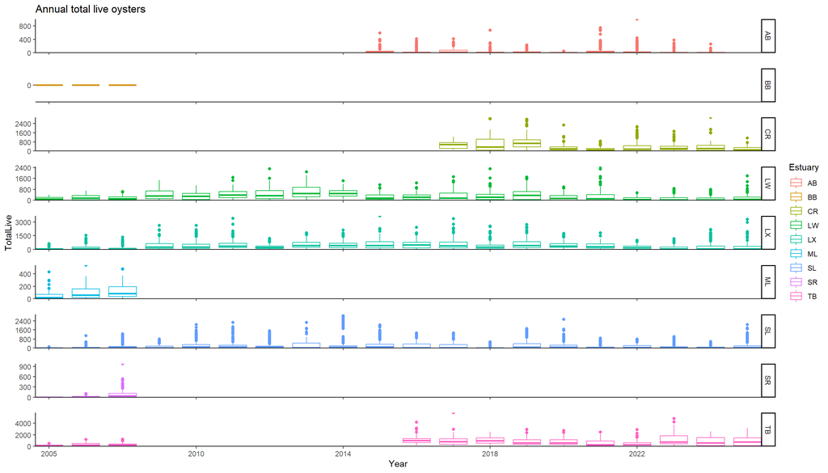

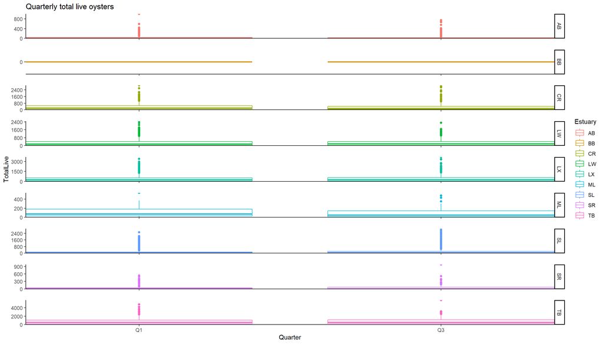

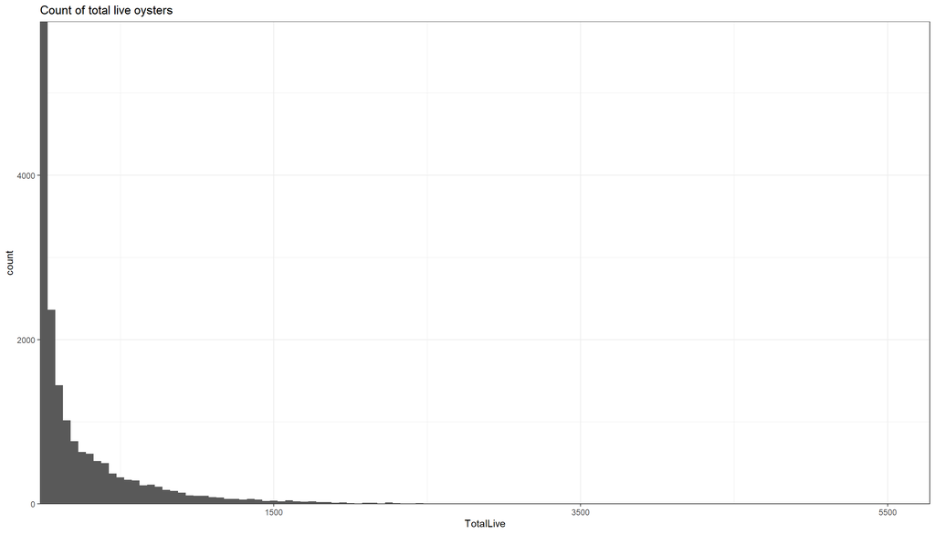

*Check distribution of data.*  
Mean: 265.864  
Variance: 172459.814  
Variance is MUCH GREATER than the mean (Overdispersion detected): Negative binomial  
Remove BB samples since all data is 0s.

# Background

Survey data limited to Q1 (Jan-Mar) and Q3 (Jul-Sep) for best comparison among sites. Surveys are divided by “Fixed” and “Random” for comparisons.  
Fixed = planned repeated sampling stations  
Random = single sampling event or station that is selected randomly for survey and has the potential for re-sampling if same station is selected across time  
Data is assessed at the quadrat level for comparisons.

# Fixed location surveys

List of sites included:  
AB CR LW LX ML SL SR TB

| Estuary | 2005 | 2006 | 2007 | 2009 | 2010 | 2011 | 2012 | 2013 | 2014 | 2015 | 2016 | 2017 | 2018 | 2019 | 2020 | 2021 | 2022 | 2023 | 2024 | 2025 |
| --- | --- | --- | --- | --- | --- | --- | --- | --- | --- | --- | --- | --- | --- | --- | --- | --- | --- | --- | --- | --- |
| LW | 60 | 60 | 120 | 90 | 90 | 90 | 93 | 96 | 96 | 135 | 180 | 180 | 180 | 180 | 180 | 180 | 180 | 180 | 180 | 180 |
| LX | 120 | 120 | 240 | 180 | 195 | 210 | 183 | 186 | 186 | 180 | 180 | 180 | 180 | 180 | 180 | 180 | 180 | 180 | 180 | 180 |
| ML | 40 | 60 | 120 |  |  |  |  |  |  |  |  |  |  |  |  |  |  |  |  |  |
| SL | 180 | 180 | 360 | 300 | 450 | 450 | 273 | 141 | 306 | 300 | 150 | 150 | 285 | 270 | 270 | 270 | 270 | 270 | 270 | 270 |
| SR | 60 | 60 | 120 |  |  |  |  |  |  |  |  |  |  |  |  |  |  |  |  |  |
| TB | 60 | 56 | 115 |  |  |  |  |  |  |  | 150 | 150 | 150 | 150 | 150 | 150 | 150 | 60 | 60 | 80 |
| AB |  |  |  |  |  |  |  |  |  | 235 | 245 | 165 | 255 | 245 | 150 | 405 | 450 | 195 | 120 |  |
| CR |  |  |  |  |  |  |  |  |  |  |  | 16 | 32 | 76 | 120 | 120 | 120 | 150 | 120 | 120 |

# Statewide

## Analayses

### Model comps

Average live oyster density

| Estuary | Mean | SE |
| --- | --- | --- |
| AB | 29.32 | 1.37 |
| CR | 355.14 | 15.11 |
| LW | 274.57 | 6.18 |
| LX | 394.70 | 7.33 |
| ML | 105.15 | 7.36 |
| SL | 167.82 | 4.16 |
| SR | 54.73 | 7.48 |
| TB | 736.46 | 17.75 |

Check if zeros makes sense.

| StationID | n | prop_zero |
| --- | --- | --- |
| AB.W.5 | 180 | 0.9222222 |
| AB.W.3 | 150 | 0.6400000 |
| AB.W.1 | 180 | 0.6222222 |
| AB.W.4 | 170 | 0.5823529 |
| AB.C.8 | 165 | 0.5696970 |

**Analyses:**  
Fixed effects - Estuary, Quarter, Year (Except m6)  
Random effects - Section, Station (sampling unit), Year (m6)  
*Do estuaries differ after accounting for annual and seasonal variation and repeated sampling?*  
**Compare models:**

| Model_Name | Description | AIC | Formula | ZI |
| --- | --- | --- | --- | --- |
| Model 1 | Starting model | 196768.1 | Live ~ Estuary + Year + Quarter + (1 \| SectionID) + (1 \| StationID) | ~0 |
| Model 2 | ZI model | 194619.6 | Live ~ Estuary + Year + Quarter + (1 \| SectionID) + (1 \| StationID) | ~1 |
| Model 3 | Zeros vary within Estuary and Quarter | 193424.7 | Live ~ Estuary + Year + Quarter + (1 \| SectionID) + (1 \| StationID) | ~Estuary + Quarter |
| Model 4 | m3 + temporal trend | 194719.9 | Live ~ Estuary + Year_n + Quarter + (1 \| SectionID) + (1 \| StationID) | ~Estuary + Quarter |
| Model 5 | m3 + estuaries can have different seasonal trends | 193266.0 | Live ~ Estuary * Quarter + Year + (1 \| SectionID) + (1 \| StationID) | ~Estuary + Quarter |
| Model 6 | m5 but Year as random effect | 193342.6 | Live ~ Estuary * Quarter + (1 \| Year) + (1 \| SectionID) + (1 \| StationID) | ~Estuary + Quarter |

[1] “model5”  
The model with the lowest AIC is: model5

**Model assessment:**  
Residuals:

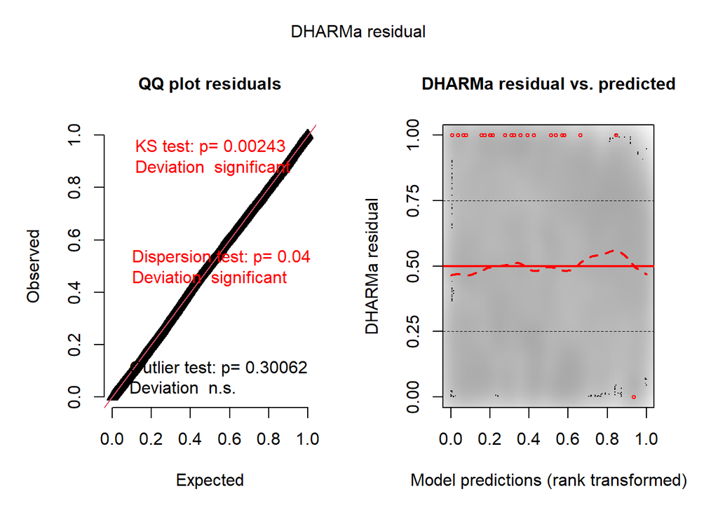

Overdispersion:  
Dispersion ratio > 1 → overdispersion  
Dispersion ratio < 1 → underdispersion

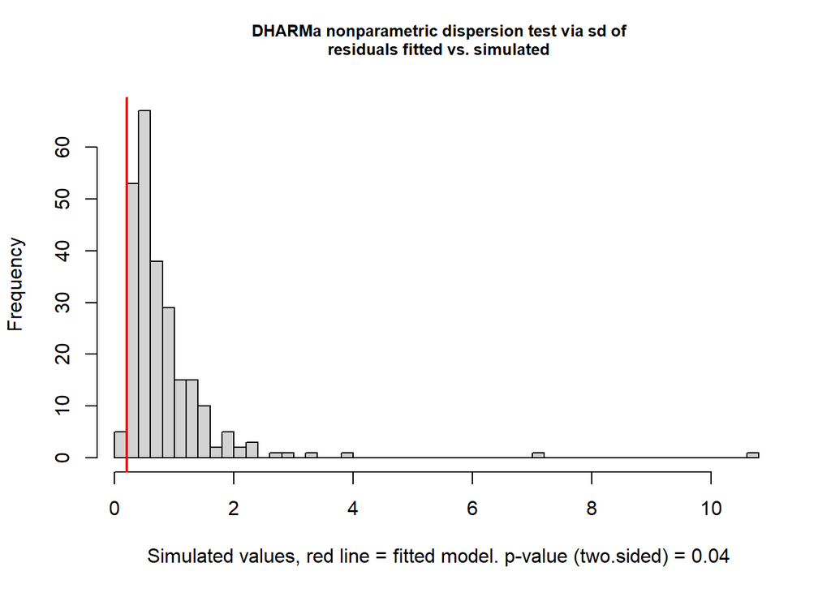

DHARMa nonparametric dispersion test via sd of residuals fitted vs. simulated

data: simulationOutput dispersion = 0.24545, p-value = 0.04 alternative hypothesis: two.sided

Underdispersion less concerning than overdispersion. Likely most explained by station variance.

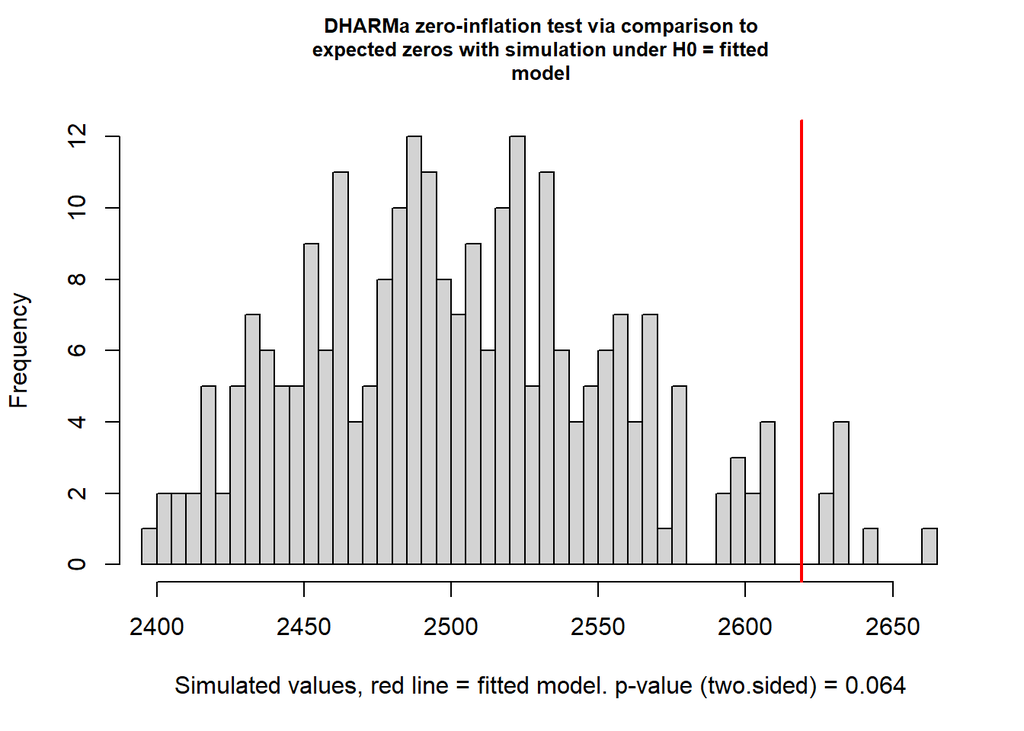

DHARMa zero-inflation test via comparison to expected zeros with simulation under H0 = fitted model

data: simulationOutput ratioObsSim = 1.0459, p-value = 0.064 alternative hypothesis: two.sided

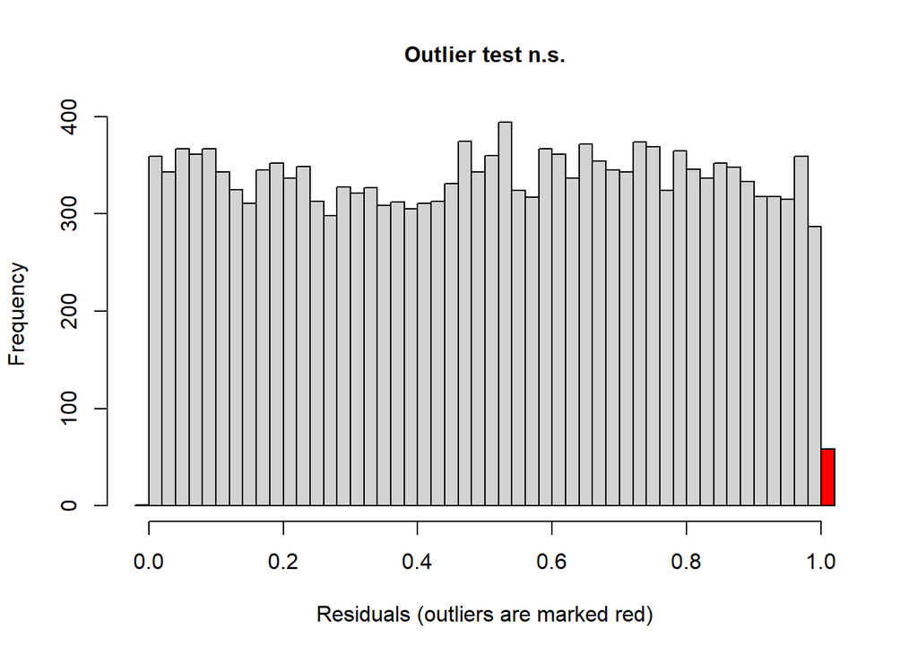

outliers at both margin(s) 123  
Parameter: observations 17023  
p_value: [1] 0.3006247  
Conf int: [1] 0.006008608 0.008615043 attr(,“conf.level”) [1] 0.95

Estuary model results

| term | statistic | df | p.value |
| --- | --- | --- | --- |
| Estuary | 83.179 | 7.000 | 0.000 |
| Quarter | 24.102 | 1.000 | 0.000 |
| Year | 1,662.592 | 19.000 | 0.000 |
| Estuary:Quarter | 169.071 | 7.000 | 0.000 |

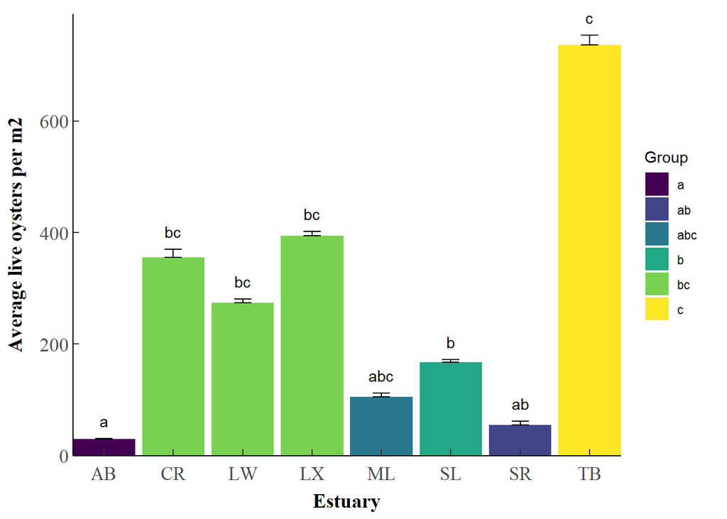

| Estuary | Samples | meanLive | sdLive | seLive | minLive | maxLive | Group |
| --- | --- | --- | --- | --- | --- | --- | --- |
| AB | 2465 | 29.32 | 68.09 | 1.37 | 0.00 | 1,008.00 | a |
| CR | 874 | 355.14 | 446.66 | 15.11 | 0.00 | 2,920.00 | bc |
| LW | 2730 | 274.57 | 322.93 | 6.18 | 0.00 | 2,456.00 | bc |
| LX | 3600 | 394.70 | 439.67 | 7.33 | 0.00 | 3,664.00 | bc |
| ML | 220 | 105.15 | 109.23 | 7.36 | 0.00 | 541.00 | abc |
| SL | 5415 | 167.82 | 306.19 | 4.16 | 0.00 | 2,988.00 | b |
| SR | 240 | 54.73 | 115.91 | 7.48 | 0.00 | 984.00 | ab |
| TB | 1481 | 736.46 | 683.13 | 17.75 | 0.00 | 5,756.00 | c |

### Model post-hoc

**Model post-hoc:**  
Q: When accounting for the zero-inflation process, how does expected oyster abundance vary among Estuaries and Quarters? (Live ~ Estuary * Quarter + Year) > Estimated marginal mean live oyster abundance by estuary and quarter, with Tukey-adjusted pairwise comparisons.  
Q: How does the probability of an additional/structural zero vary among Estuaries and Quarters? (ziformula = ~ Estuary + Quarter) > Estimated probability of a structural zero by estuary and quarter, with Tukey-adjusted pairwise comparisons.  
*Is live abundance different among estuaries?*  
Likelihood-ratio test  
*Test Estuary effects*:

|  | Df | AIC | BIC | logLik | deviance | Chisq | Chi Df | Pr(>Chisq) |
| --- | --- | --- | --- | --- | --- | --- | --- | --- |
| m_noEstuary | 33 | 193445.1 | 193700.6 | -96689.56 | 193379.1 | NA | NA | NA |
| model5 | 47 | 193266.0 | 193629.9 | -96586.02 | 193172.0 | 207.0925 | 14 | 1.947882e-36 |

p < 0.001. Estuary effect is significant = difference among estuaries.  
Mean data with groups:

| Estuary | Samples | meanLive | sdLive | seLive | minLive | maxLive | Group |
| --- | --- | --- | --- | --- | --- | --- | --- |
| AB | 2465 | 29.32 | 68.09 | 1.37 | 0.00 | 1,008.00 | a |
| CR | 874 | 355.14 | 446.66 | 15.11 | 0.00 | 2,920.00 | bc |
| LW | 2730 | 274.57 | 322.93 | 6.18 | 0.00 | 2,456.00 | bc |
| LX | 3600 | 394.70 | 439.67 | 7.33 | 0.00 | 3,664.00 | bc |
| ML | 220 | 105.15 | 109.23 | 7.36 | 0.00 | 541.00 | abc |
| SL | 5415 | 167.82 | 306.19 | 4.16 | 0.00 | 2,988.00 | b |
| SR | 240 | 54.73 | 115.91 | 7.48 | 0.00 | 984.00 | ab |
| TB | 1481 | 736.46 | 683.13 | 17.75 | 0.00 | 5,756.00 | c |

*Estimated marginal means*: Adjusted means accounting for year, quarter, random effects, and zero-inflation.

| Estuary | response | SE | df | asymp.LCL | asymp.UCL |
| --- | --- | --- | --- | --- | --- |
| AB | 32.440 | 9.075 | Inf | 18.749 | 56.131 |
| CR | 364.208 | 155.381 | Inf | 157.835 | 840.419 |
| LW | 249.860 | 92.390 | Inf | 121.046 | 515.755 |
| LX | 285.965 | 98.091 | Inf | 145.994 | 560.132 |
| ML | 164.855 | 89.800 | Inf | 56.681 | 479.480 |
| SL | 109.878 | 25.553 | Inf | 69.657 | 173.325 |
| SR | 67.291 | 36.782 | Inf | 23.051 | 196.441 |
| TB | 894.181 | 284.666 | Inf | 479.118 | 1,668.819 |

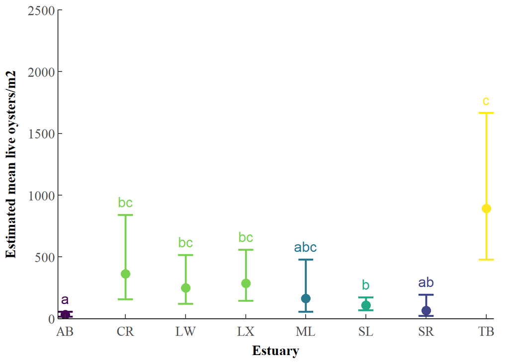

*Pairwise comparisons*: Correction for multiple comparisons.

| contrast | ratio | SE | df | null | z.ratio | p.value | Significance |
| --- | --- | --- | --- | --- | --- | --- | --- |
| AB / CR | 0.089 | 0.045 | Inf | 1.000 | −4.742 | 0.000 | *** |
| AB / LW | 0.130 | 0.060 | Inf | 1.000 | −4.404 | 0.000 | *** |
| AB / LX | 0.113 | 0.050 | Inf | 1.000 | −4.919 | 0.000 | *** |
| AB / ML | 0.197 | 0.121 | Inf | 1.000 | −2.654 | 0.137 |  |
| AB / SL | 0.295 | 0.107 | Inf | 1.000 | −3.352 | 0.018 | * |
| AB / SR | 0.482 | 0.296 | Inf | 1.000 | −1.188 | 0.936 |  |
| AB / TB | 0.036 | 0.015 | Inf | 1.000 | −7.820 | 0.000 | *** |
| CR / LW | 1.458 | 0.823 | Inf | 1.000 | 0.668 | 0.998 |  |
| CR / LX | 1.274 | 0.697 | Inf | 1.000 | 0.442 | 1.000 |  |
| CR / ML | 2.209 | 1.529 | Inf | 1.000 | 1.145 | 0.947 |  |
| CR / SL | 3.315 | 1.611 | Inf | 1.000 | 2.466 | 0.210 |  |
| CR / SR | 5.412 | 3.753 | Inf | 1.000 | 2.435 | 0.224 |  |
| CR / TB | 0.407 | 0.217 | Inf | 1.000 | −1.688 | 0.695 |  |
| LW / LX | 0.874 | 0.441 | Inf | 1.000 | −0.268 | 1.000 |  |
| LW / ML | 1.516 | 0.998 | Inf | 1.000 | 0.632 | 0.998 |  |
| LW / SL | 2.274 | 0.993 | Inf | 1.000 | 1.881 | 0.564 |  |
| LW / SR | 3.713 | 2.451 | Inf | 1.000 | 1.988 | 0.490 |  |
| LW / TB | 0.279 | 0.136 | Inf | 1.000 | −2.613 | 0.151 |  |
| LX / ML | 1.735 | 1.117 | Inf | 1.000 | 0.856 | 0.990 |  |
| LX / SL | 2.603 | 1.079 | Inf | 1.000 | 2.307 | 0.290 |  |
| LX / SR | 4.250 | 2.743 | Inf | 1.000 | 2.242 | 0.327 |  |
| LX / TB | 0.320 | 0.150 | Inf | 1.000 | −2.429 | 0.227 |  |
| ML / SL | 1.500 | 0.889 | Inf | 1.000 | 0.685 | 0.997 |  |
| ML / SR | 2.450 | 1.889 | Inf | 1.000 | 1.162 | 0.942 |  |
| ML / TB | 0.184 | 0.116 | Inf | 1.000 | −2.679 | 0.129 |  |
| SL / SR | 1.633 | 0.970 | Inf | 1.000 | 0.826 | 0.992 |  |
| SL / TB | 0.123 | 0.048 | Inf | 1.000 | −5.325 | 0.000 | *** |
| SR / TB | 0.075 | 0.048 | Inf | 1.000 | −4.089 | 0.001 | ** |

*Test Quarter effects*:

|  | Df | AIC | BIC | logLik | deviance | Chisq | Chi Df | Pr(>Chisq) |
| --- | --- | --- | --- | --- | --- | --- | --- | --- |
| m_noQuarter | 39 | 193445.5 | 193747.5 | -96683.76 | 193367.5 | NA | NA | NA |
| model5 | 47 | 193266.0 | 193629.9 | -96586.02 | 193172.0 | 195.4919 | 8 | 5.688742e-38 |

p < 0.001. Quarter effect is significant = difference among quarters  
Mean data with groups:

| Quarter | Samples | meanLive | sdLive | seLive | Group |
| --- | --- | --- | --- | --- | --- |
| Q1 | 8041 | 278.22 | 415.27 | 4.63 | a |
| Q3 | 8984 | 261.74 | 419.82 | 4.43 | b |

*Estimated marginal means*: Adjusted means accounting for year, quarter, random effects, and zero-inflation.

| Quarter | response | SE | df | asymp.LCL | asymp.UCL |
| --- | --- | --- | --- | --- | --- |
| Q1 | 166.247 | 23.481 | Inf | 126.046 | 219.269 |
| Q3 | 186.298 | 26.391 | Inf | 141.133 | 245.917 |

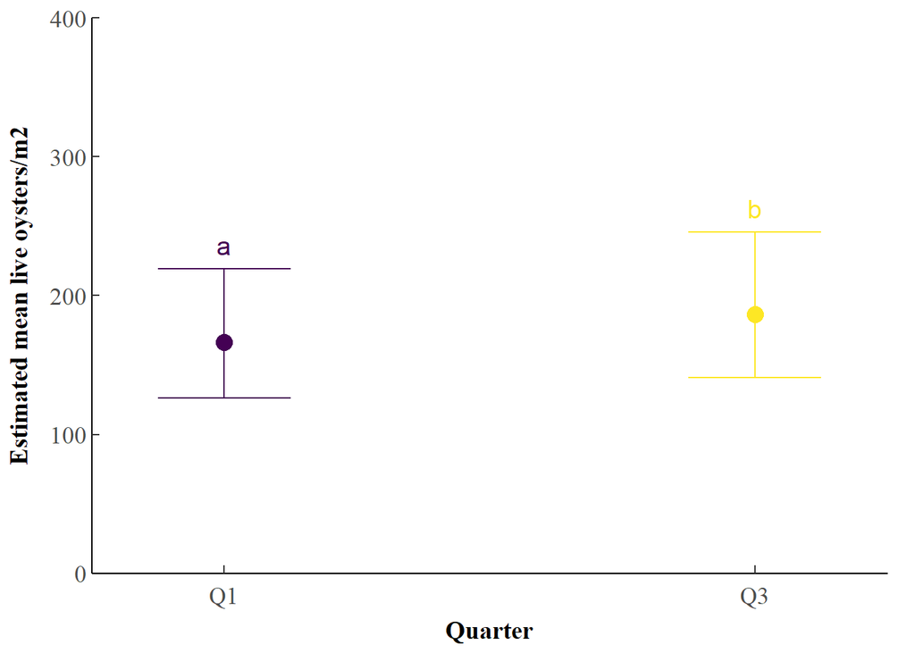

*Pairwise comparisons*: Correction for multiple comparisons.

| contrast | ratio | SE | df | null | z.ratio | p.value | Significance |
| --- | --- | --- | --- | --- | --- | --- | --- |
| Q1 / Q3 | 0.892 | 0.028 | Inf | 1.000 | −3.614 | 0.000 | *** |

*Test interaction effects*:

|  | Df | AIC | BIC | logLik | deviance | Chisq | Chi Df | Pr(>Chisq) |
| --- | --- | --- | --- | --- | --- | --- | --- | --- |
| m_noInteraction | 40 | 193424.7 | 193734.4 | -96672.35 | 193344.7 | NA | NA | NA |
| model5 | 47 | 193266.0 | 193629.9 | -96586.02 | 193172.0 | 172.6719 | 7 | 6.859338e-34 |

p < 0.001. Interaction effect is significant = difference in quarters among estuaries.

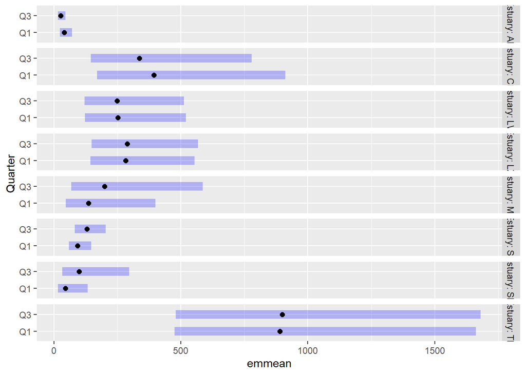

Check differeneces among estuaries within quarter and within quarter among estuaries to best understand the interaction.  
*Estuary differences within Quarters*  
Mean data with groups:

| Quarter | Estuary | Samples | meanLive | sdLive | seLive | Group |
| --- | --- | --- | --- | --- | --- | --- |
| Q1 | AB | 470 | 42.37 | 88.62 | 4.09 | a |
| Q1 | CR | 438 | 363.75 | 411.63 | 19.67 | cd |
| Q1 | LW | 1371 | 272.71 | 333.42 | 9.00 | bcd |
| Q1 | LX | 1851 | 385.12 | 424.91 | 9.88 | bcd |
| Q1 | ML | 130 | 111.98 | 104.67 | 9.18 | abcd |
| Q1 | SL | 2856 | 137.13 | 254.59 | 4.76 | abc |
| Q1 | SR | 150 | 48.10 | 97.38 | 7.95 | ab |
| Q1 | TB | 775 | 720.04 | 686.16 | 24.65 | d |
| Q3 | AB | 1995 | 26.25 | 61.90 | 1.39 | a |
| Q3 | CR | 436 | 346.50 | 479.60 | 22.97 | bc |
| Q3 | LW | 1359 | 276.45 | 312.11 | 8.47 | bc |
| Q3 | LX | 1749 | 404.83 | 454.64 | 10.87 | bc |
| Q3 | ML | 90 | 95.28 | 115.37 | 12.16 | bc |
| Q3 | SL | 2559 | 202.07 | 351.93 | 6.96 | b |
| Q3 | SR | 90 | 65.77 | 141.45 | 14.91 | ab |
| Q3 | TB | 706 | 754.49 | 679.83 | 25.59 | c |

*Estimated marginal means*: Adjusted means accounting for year, random effects, and zero-inflation.

| Estuary | Quarter | response | SE | df | asymp.LCL | asymp.UCL |
| --- | --- | --- | --- | --- | --- | --- |
| AB | Q1 | 40.373 | 11.486 | Inf | 23.117 | 70.511 |
| CR | Q1 | 393.873 | 168.585 | Inf | 170.227 | 911.351 |
| LW | Q1 | 251.703 | 93.210 | Inf | 121.807 | 520.120 |
| LX | Q1 | 282.767 | 97.107 | Inf | 144.249 | 554.300 |
| ML | Q1 | 136.500 | 74.713 | Inf | 46.691 | 399.059 |
| SL | Q1 | 93.257 | 21.737 | Inf | 59.058 | 147.262 |
| SR | Q1 | 45.532 | 24.989 | Inf | 15.529 | 133.499 |
| TB | Q1 | 889.469 | 283.979 | Inf | 475.739 | 1,663.002 |
| AB | Q3 | 26.067 | 7.274 | Inf | 15.085 | 45.042 |
| CR | Q3 | 336.778 | 144.147 | Inf | 145.550 | 779.245 |
| LW | Q3 | 248.030 | 91.859 | Inf | 120.021 | 512.568 |
| LX | Q3 | 289.199 | 99.328 | Inf | 147.518 | 566.956 |
| ML | Q3 | 199.101 | 109.806 | Inf | 67.551 | 586.838 |
| SL | Q3 | 129.461 | 30.166 | Inf | 81.998 | 204.399 |
| SR | Q3 | 99.450 | 55.343 | Inf | 33.413 | 296.000 |
| TB | Q3 | 898.919 | 287.250 | Inf | 480.528 | 1,681.599 |

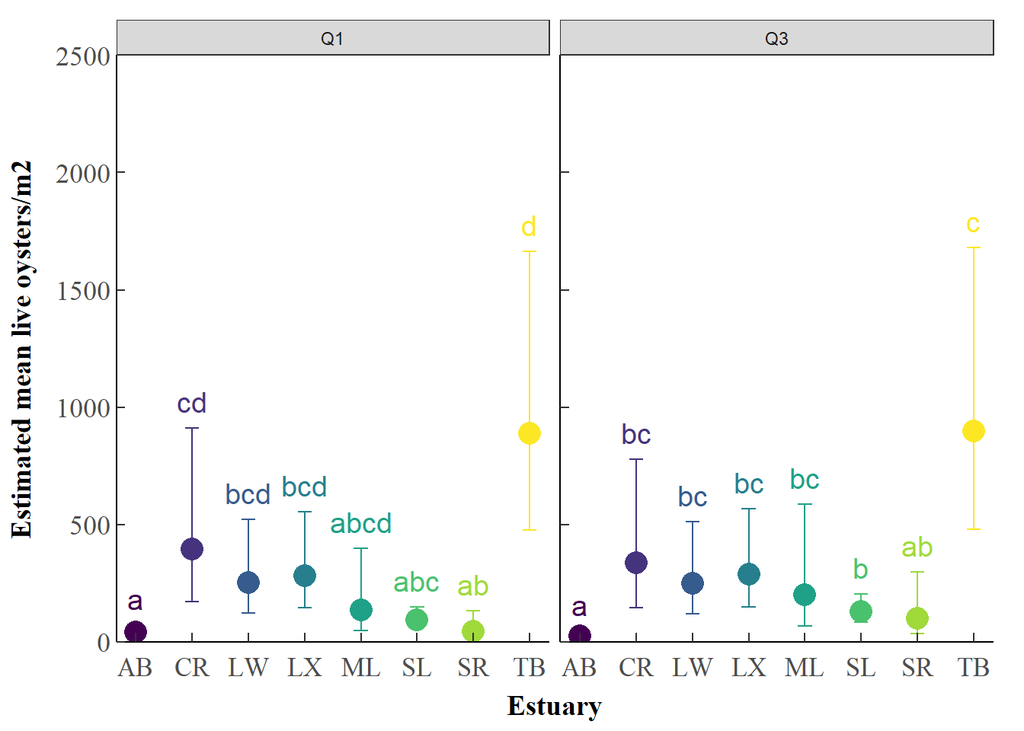

*Pairwise comparisons*: Correction for multiple comparisons.

| contrast | Quarter | ratio | SE | df | null | z.ratio | p.value | Significance |
| --- | --- | --- | --- | --- | --- | --- | --- | --- |
| AB / CR | Q1 | 0.103 | 0.053 | Inf | 1.000 | −4.435 | 0.000 | *** |
| AB / LW | Q1 | 0.160 | 0.075 | Inf | 1.000 | −3.920 | 0.002 | ** |
| AB / LX | Q1 | 0.143 | 0.064 | Inf | 1.000 | −4.367 | 0.000 | *** |
| AB / ML | Q1 | 0.296 | 0.182 | Inf | 1.000 | −1.974 | 0.499 |  |
| AB / SL | Q1 | 0.433 | 0.159 | Inf | 1.000 | −2.275 | 0.307 |  |
| AB / SR | Q1 | 0.887 | 0.548 | Inf | 1.000 | −0.194 | 1.000 |  |
| AB / TB | Q1 | 0.045 | 0.019 | Inf | 1.000 | −7.226 | 0.000 | *** |
| CR / LW | Q1 | 1.565 | 0.886 | Inf | 1.000 | 0.791 | 0.994 |  |
| CR / LX | Q1 | 1.393 | 0.764 | Inf | 1.000 | 0.604 | 0.999 |  |
| CR / ML | Q1 | 2.886 | 2.005 | Inf | 1.000 | 1.525 | 0.794 |  |
| CR / SL | Q1 | 4.224 | 2.059 | Inf | 1.000 | 2.956 | 0.062 |  |
| CR / SR | Q1 | 8.651 | 6.022 | Inf | 1.000 | 3.100 | 0.041 | * |
| CR / TB | Q1 | 0.443 | 0.236 | Inf | 1.000 | −1.526 | 0.793 |  |
| LW / LX | Q1 | 0.890 | 0.450 | Inf | 1.000 | −0.230 | 1.000 |  |
| LW / ML | Q1 | 1.844 | 1.219 | Inf | 1.000 | 0.926 | 0.984 |  |
| LW / SL | Q1 | 2.699 | 1.181 | Inf | 1.000 | 2.269 | 0.311 |  |
| LW / SR | Q1 | 5.528 | 3.660 | Inf | 1.000 | 2.583 | 0.162 |  |
| LW / TB | Q1 | 0.283 | 0.138 | Inf | 1.000 | −2.582 | 0.162 |  |
| LX / ML | Q1 | 2.072 | 1.339 | Inf | 1.000 | 1.127 | 0.951 |  |
| LX / SL | Q1 | 3.032 | 1.259 | Inf | 1.000 | 2.671 | 0.131 |  |
| LX / SR | Q1 | 6.210 | 4.021 | Inf | 1.000 | 2.821 | 0.090 |  |
| LX / TB | Q1 | 0.318 | 0.149 | Inf | 1.000 | −2.437 | 0.223 |  |
| ML / SL | Q1 | 1.464 | 0.871 | Inf | 1.000 | 0.640 | 0.998 |  |
| ML / SR | Q1 | 2.998 | 2.321 | Inf | 1.000 | 1.418 | 0.849 |  |
| ML / TB | Q1 | 0.153 | 0.097 | Inf | 1.000 | −2.958 | 0.062 |  |
| SL / SR | Q1 | 2.048 | 1.221 | Inf | 1.000 | 1.203 | 0.931 |  |
| SL / TB | Q1 | 0.105 | 0.041 | Inf | 1.000 | −5.713 | 0.000 | *** |
| SR / TB | Q1 | 0.051 | 0.033 | Inf | 1.000 | −4.681 | 0.000 | *** |
| AB / CR | Q3 | 0.077 | 0.040 | Inf | 1.000 | −5.010 | 0.000 | *** |
| AB / LW | Q3 | 0.105 | 0.049 | Inf | 1.000 | −4.859 | 0.000 | *** |
| AB / LX | Q3 | 0.090 | 0.040 | Inf | 1.000 | −5.440 | 0.000 | *** |
| AB / ML | Q3 | 0.131 | 0.081 | Inf | 1.000 | −3.288 | 0.023 | * |
| AB / SL | Q3 | 0.201 | 0.073 | Inf | 1.000 | −4.406 | 0.000 | *** |
| AB / SR | Q3 | 0.262 | 0.163 | Inf | 1.000 | −2.150 | 0.382 |  |
| AB / TB | Q3 | 0.029 | 0.012 | Inf | 1.000 | −8.341 | 0.000 | *** |
| CR / LW | Q3 | 1.358 | 0.768 | Inf | 1.000 | 0.540 | 0.999 |  |
| CR / LX | Q3 | 1.165 | 0.639 | Inf | 1.000 | 0.278 | 1.000 |  |
| CR / ML | Q3 | 1.691 | 1.181 | Inf | 1.000 | 0.753 | 0.995 |  |
| CR / SL | Q3 | 2.601 | 1.268 | Inf | 1.000 | 1.962 | 0.508 |  |
| CR / SR | Q3 | 3.386 | 2.378 | Inf | 1.000 | 1.737 | 0.663 |  |
| CR / TB | Q3 | 0.375 | 0.200 | Inf | 1.000 | −1.839 | 0.593 |  |
| LW / LX | Q3 | 0.858 | 0.433 | Inf | 1.000 | −0.304 | 1.000 |  |
| LW / ML | Q3 | 1.246 | 0.828 | Inf | 1.000 | 0.331 | 1.000 |  |
| LW / SL | Q3 | 1.916 | 0.838 | Inf | 1.000 | 1.486 | 0.815 |  |
| LW / SR | Q3 | 2.494 | 1.667 | Inf | 1.000 | 1.367 | 0.872 |  |
| LW / TB | Q3 | 0.276 | 0.135 | Inf | 1.000 | −2.633 | 0.144 |  |
| LX / ML | Q3 | 1.453 | 0.944 | Inf | 1.000 | 0.574 | 0.999 |  |
| LX / SL | Q3 | 2.234 | 0.928 | Inf | 1.000 | 1.936 | 0.526 |  |
| LX / SR | Q3 | 2.908 | 1.902 | Inf | 1.000 | 1.632 | 0.731 |  |
| LX / TB | Q3 | 0.322 | 0.151 | Inf | 1.000 | −2.411 | 0.236 |  |
| ML / SL | Q3 | 1.538 | 0.921 | Inf | 1.000 | 0.719 | 0.996 |  |
| ML / SR | Q3 | 2.002 | 1.568 | Inf | 1.000 | 0.886 | 0.987 |  |
| ML / TB | Q3 | 0.221 | 0.141 | Inf | 1.000 | −2.365 | 0.259 |  |
| SL / SR | Q3 | 1.302 | 0.785 | Inf | 1.000 | 0.437 | 1.000 |  |
| SL / TB | Q3 | 0.144 | 0.057 | Inf | 1.000 | −4.907 | 0.000 | *** |
| SR / TB | Q3 | 0.111 | 0.071 | Inf | 1.000 | −3.430 | 0.014 | * |

*Quarter differences within Estuaries*  
Mean data with groups:

| Estuary | Quarter | Samples | meanLive | sdLive | seLive | Group |
| --- | --- | --- | --- | --- | --- | --- |
| AB | Q1 | 470 | 42.37 | 88.62 | 4.09 | b |
| AB | Q3 | 1995 | 26.25 | 61.90 | 1.39 | a |
| CR | Q1 | 438 | 363.75 | 411.63 | 19.67 | b |
| CR | Q3 | 436 | 346.50 | 479.60 | 22.97 | a |
| LW | Q1 | 1371 | 272.71 | 333.42 | 9.00 | a |
| LW | Q3 | 1359 | 276.45 | 312.11 | 8.47 | a |
| LX | Q1 | 1851 | 385.12 | 424.91 | 9.88 | a |
| LX | Q3 | 1749 | 404.83 | 454.64 | 10.87 | a |
| ML | Q1 | 130 | 111.98 | 104.67 | 9.18 | a |
| ML | Q3 | 90 | 95.28 | 115.37 | 12.16 | b |
| SL | Q1 | 2856 | 137.13 | 254.59 | 4.76 | a |
| SL | Q3 | 2559 | 202.07 | 351.93 | 6.96 | b |
| SR | Q1 | 150 | 48.10 | 97.38 | 7.95 | a |
| SR | Q3 | 90 | 65.77 | 141.45 | 14.91 | b |
| TB | Q1 | 775 | 720.04 | 686.16 | 24.65 | a |
| TB | Q3 | 706 | 754.49 | 679.83 | 25.59 | a |

*Estimated marginal means*: Adjusted means accounting for year, random effects, and zero-inflation.

| Quarter | Estuary | response | SE | df | asymp.LCL | asymp.UCL |
| --- | --- | --- | --- | --- | --- | --- |
| Q1 | AB | 40.373 | 11.486 | Inf | 23.117 | 70.511 |
| Q3 | AB | 26.067 | 7.274 | Inf | 15.085 | 45.042 |
| Q1 | CR | 393.873 | 168.585 | Inf | 170.227 | 911.351 |
| Q3 | CR | 336.778 | 144.147 | Inf | 145.550 | 779.245 |
| Q1 | LW | 251.703 | 93.210 | Inf | 121.807 | 520.120 |
| Q3 | LW | 248.030 | 91.859 | Inf | 120.021 | 512.568 |
| Q1 | LX | 282.767 | 97.107 | Inf | 144.249 | 554.300 |
| Q3 | LX | 289.199 | 99.328 | Inf | 147.518 | 566.956 |
| Q1 | ML | 136.500 | 74.713 | Inf | 46.691 | 399.059 |
| Q3 | ML | 199.101 | 109.806 | Inf | 67.551 | 586.838 |
| Q1 | SL | 93.257 | 21.737 | Inf | 59.058 | 147.262 |
| Q3 | SL | 129.461 | 30.166 | Inf | 81.998 | 204.399 |
| Q1 | SR | 45.532 | 24.989 | Inf | 15.529 | 133.499 |
| Q3 | SR | 99.450 | 55.343 | Inf | 33.413 | 296.000 |
| Q1 | TB | 889.469 | 283.979 | Inf | 475.739 | 1,663.002 |
| Q3 | TB | 898.919 | 287.250 | Inf | 480.528 | 1,681.599 |

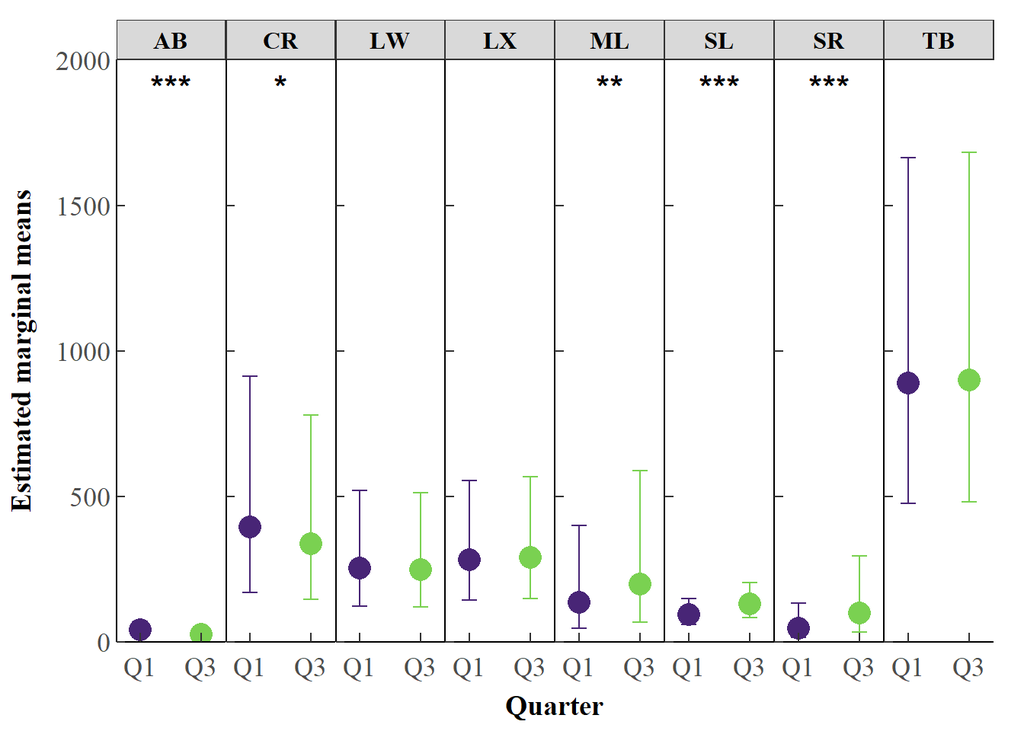

*Pairwise comparisons*: Correction for multiple comparisons.

| contrast | Estuary | ratio | SE | df | null | z.ratio | p.value | Significance |
| --- | --- | --- | --- | --- | --- | --- | --- | --- |
| Q1 / Q3 | AB | 1.549 | 0.105 | Inf | 1.000 | 6.440 | 0.000 | *** |
| Q1 / Q3 | CR | 1.170 | 0.081 | Inf | 1.000 | 2.271 | 0.023 | * |
| Q1 / Q3 | LW | 1.015 | 0.042 | Inf | 1.000 | 0.358 | 0.720 |  |
| Q1 / Q3 | LX | 0.978 | 0.033 | Inf | 1.000 | −0.663 | 0.507 |  |
| Q1 / Q3 | ML | 0.686 | 0.098 | Inf | 1.000 | −2.629 | 0.009 | ** |
| Q1 / Q3 | SL | 0.720 | 0.022 | Inf | 1.000 | −10.779 | 0.000 | *** |
| Q1 / Q3 | SR | 0.458 | 0.075 | Inf | 1.000 | −4.784 | 0.000 | *** |
| Q1 / Q3 | TB | 0.989 | 0.051 | Inf | 1.000 | −0.204 | 0.839 |  |

*Test zero-inflation effects*:  
*Do estuaries differ in their probability of being a 0?*  
*Estimated marginal means*: Adjusted means.

| Estuary | response | SE | df | asymp.LCL | asymp.UCL |
| --- | --- | --- | --- | --- | --- |
| AB | 0.359 | 0.012 | Inf | 0.337 | 0.382 |
| CR | 0.021 | 0.005 | Inf | 0.013 | 0.035 |
| LW | 0.132 | 0.007 | Inf | 0.119 | 0.145 |
| LX | 0.049 | 0.004 | Inf | 0.042 | 0.057 |
| ML | 0.036 | 0.014 | Inf | 0.016 | 0.075 |
| SL | 0.155 | 0.005 | Inf | 0.145 | 0.165 |
| SR | 0.245 | 0.031 | Inf | 0.190 | 0.311 |
| TB | 0.015 | 0.003 | Inf | 0.009 | 0.024 |

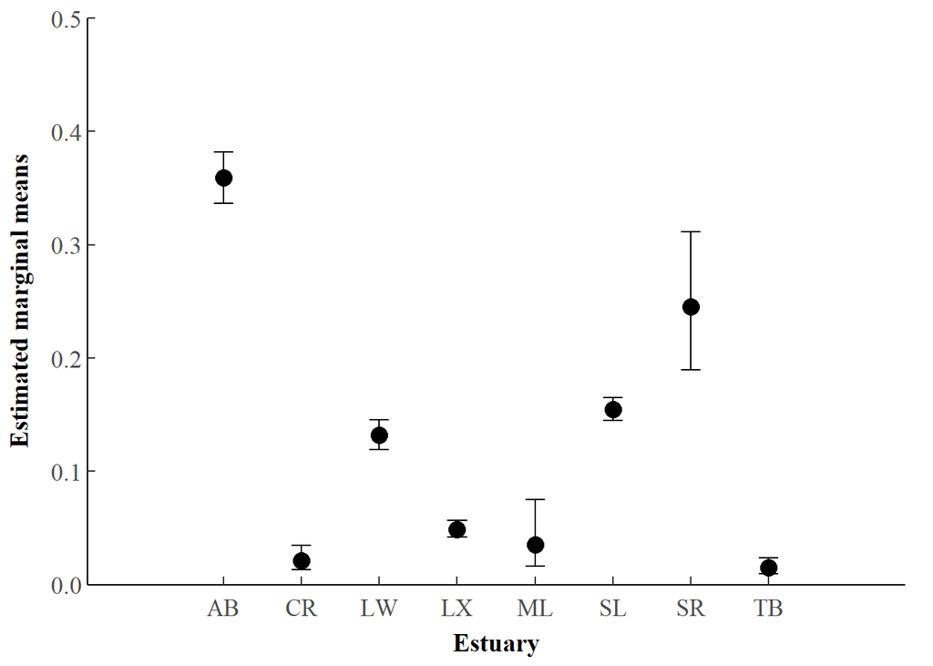

*Pairwise comparisons*: Correction for multiple comparisons.

| contrast | odds.ratio | SE | df | null | z.ratio | p.value | Significance |
| --- | --- | --- | --- | --- | --- | --- | --- |
| AB / CR | 25.639 | 6.622 | Inf | 1.000 | 12.560 | 0.000 | *** |
| AB / LW | 3.688 | 0.284 | Inf | 1.000 | 16.928 | 0.000 | *** |
| AB / LX | 10.923 | 1.052 | Inf | 1.000 | 24.816 | 0.000 | *** |
| AB / ML | 15.218 | 6.170 | Inf | 1.000 | 6.715 | 0.000 | *** |
| AB / SL | 3.061 | 0.199 | Inf | 1.000 | 17.253 | 0.000 | *** |
| AB / SR | 1.722 | 0.303 | Inf | 1.000 | 3.087 | 0.042 | * |
| AB / TB | 37.014 | 9.004 | Inf | 1.000 | 14.846 | 0.000 | *** |
| CR / LW | 0.144 | 0.037 | Inf | 1.000 | −7.469 | 0.000 | *** |
| CR / LX | 0.426 | 0.113 | Inf | 1.000 | −3.210 | 0.029 | * |
| CR / ML | 0.594 | 0.282 | Inf | 1.000 | −1.099 | 0.957 |  |
| CR / SL | 0.119 | 0.031 | Inf | 1.000 | −8.297 | 0.000 | *** |
| CR / SR | 0.067 | 0.020 | Inf | 1.000 | −8.894 | 0.000 | *** |
| CR / TB | 1.444 | 0.501 | Inf | 1.000 | 1.058 | 0.965 |  |
| LW / LX | 2.962 | 0.296 | Inf | 1.000 | 10.853 | 0.000 | *** |
| LW / ML | 4.126 | 1.675 | Inf | 1.000 | 3.491 | 0.011 | * |
| LW / SL | 0.830 | 0.058 | Inf | 1.000 | −2.648 | 0.139 |  |
| LW / SR | 0.467 | 0.083 | Inf | 1.000 | −4.285 | 0.000 | *** |
| LW / TB | 10.036 | 2.457 | Inf | 1.000 | 9.421 | 0.000 | *** |
| LX / ML | 1.393 | 0.571 | Inf | 1.000 | 0.809 | 0.993 |  |
| LX / SL | 0.280 | 0.025 | Inf | 1.000 | −14.011 | 0.000 | *** |
| LX / SR | 0.158 | 0.029 | Inf | 1.000 | −9.899 | 0.000 | *** |
| LX / TB | 3.389 | 0.852 | Inf | 1.000 | 4.856 | 0.000 | *** |
| ML / SL | 0.201 | 0.081 | Inf | 1.000 | −3.971 | 0.002 | ** |
| ML / SR | 0.113 | 0.049 | Inf | 1.000 | −5.004 | 0.000 | *** |
| ML / TB | 2.432 | 1.135 | Inf | 1.000 | 1.904 | 0.548 |  |
| SL / SR | 0.563 | 0.097 | Inf | 1.000 | −3.335 | 0.019 | * |
| SL / TB | 12.091 | 2.915 | Inf | 1.000 | 10.339 | 0.000 | *** |
| SR / TB | 21.489 | 6.250 | Inf | 1.000 | 10.547 | 0.000 | *** |

*Do quarters differ in their probability of being a 0?*  
*Estimated marginal means*: Adjusted means.

| Quarter | response | SE | df | asymp.LCL | asymp.UCL |
| --- | --- | --- | --- | --- | --- |
| Q1 | 0.086 | 0.006 | Inf | 0.075 | 0.099 |
| Q3 | 0.074 | 0.005 | Inf | 0.064 | 0.084 |

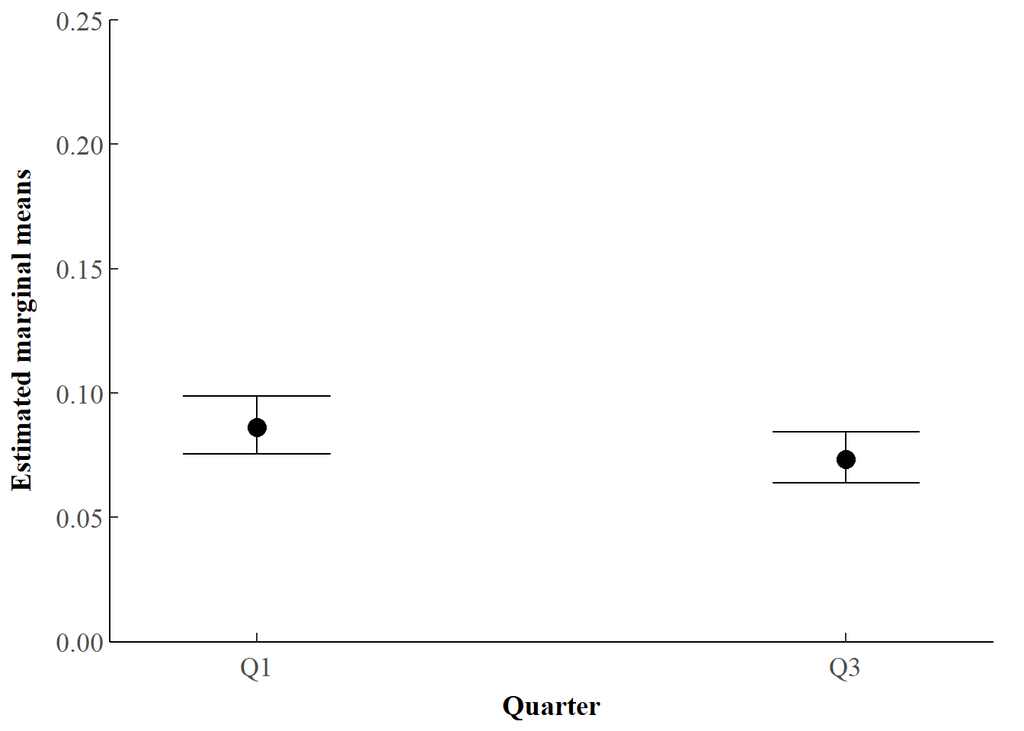

*Pairwise comparisons*: Correction for multiple comparisons.

| contrast | odds.ratio | SE | df | null | z.ratio | p.value | Significance |
| --- | --- | --- | --- | --- | --- | --- | --- |
| Q1 / Q3 | 1.191 | 0.063 | Inf | 1.000 | 3.329 | 0.001 | *** |

**Summary:** The mean number of live oysters surveyed ranged from 29.3 oysters/m2 in AB to 736.5 oysters/m2 in TB with an overall average of 264.7 +/- 233.6 oysters/m2.

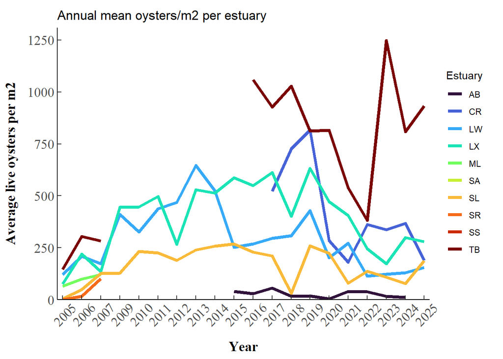

# Panhandle estuaries

## Apalachicola Bay

### Estuary-wide

**Background information:**

Average live oyster density

| Year | Mean | SE |
| --- | --- | --- |
| 2015 | 38.96 | 4.72 |
| 2016 | 28.52 | 3.83 |
| 2017 | 56.73 | 6.53 |
| 2018 | 16.30 | 3.35 |
| 2019 | 17.86 | 2.10 |
| 2020 | 4.72 | 0.63 |
| 2021 | 40.12 | 4.31 |
| 2022 | 37.33 | 3.93 |
| 2023 | 16.04 | 3.39 |
| 2024 | 11.30 | 2.69 |

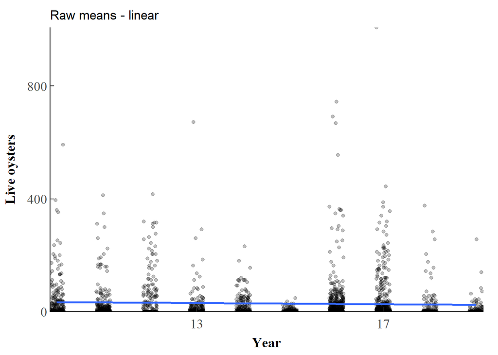

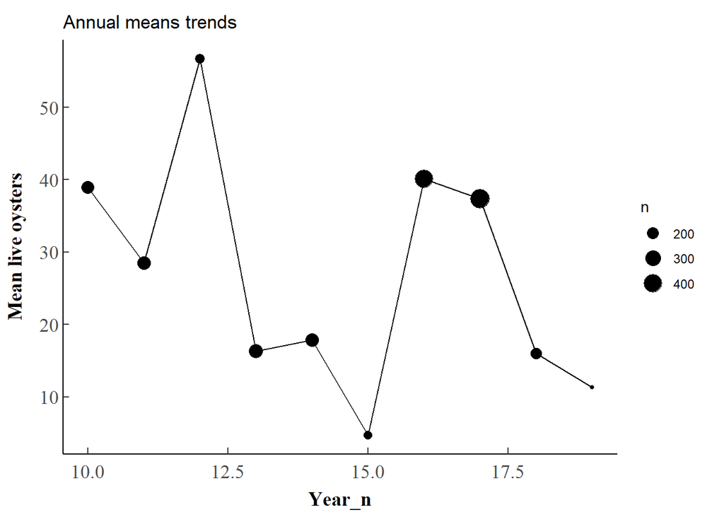

Amount of 0s

| Year | n | zeros | zero_pct | mean |
| --- | --- | --- | --- | --- |
| 2015 | 235.00 | 73.00 | 31.06 | 38.96 |
| 2016 | 245.00 | 90.00 | 36.73 | 28.52 |
| 2017 | 165.00 | 63.00 | 38.18 | 56.73 |
| 2018 | 255.00 | 130.00 | 50.98 | 16.30 |
| 2019 | 245.00 | 122.00 | 49.80 | 17.86 |
| 2020 | 150.00 | 79.00 | 52.67 | 4.72 |
| 2021 | 405.00 | 87.00 | 21.48 | 40.12 |
| 2022 | 450.00 | 153.00 | 34.00 | 37.33 |
| 2023 | 195.00 | 122.00 | 62.56 | 16.04 |
| 2024 | 120.00 | 61.00 | 50.83 | 11.30 |

**Analyses:**  
GLMM model with negative binomial distribution, log link Fixed effects - Year, Quarter  
Random effects - Station (sampling unit)  
Year = continuous to identify trend. Centered to interpret trend at middle timepoint of surveys.  
*Has density changed over time?*

Standard vs 0-inflated

|  | df | AIC |
| --- | --- | --- |
| ABm0 | 6 | 17074.58 |
| ABm01 | 8 | 16959.85 |

**Estuary model assessment:** ABm01  
Residuals:

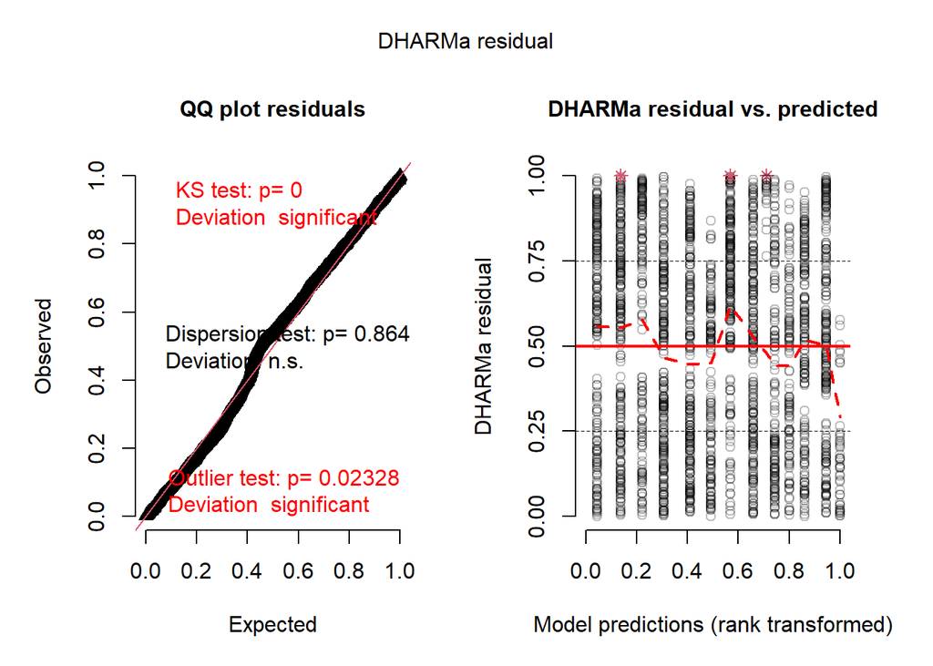

Overdispersion:  
Dispersion ratio > 1 → overdispersion  
Dispersion ratio < 1 → underdispersion

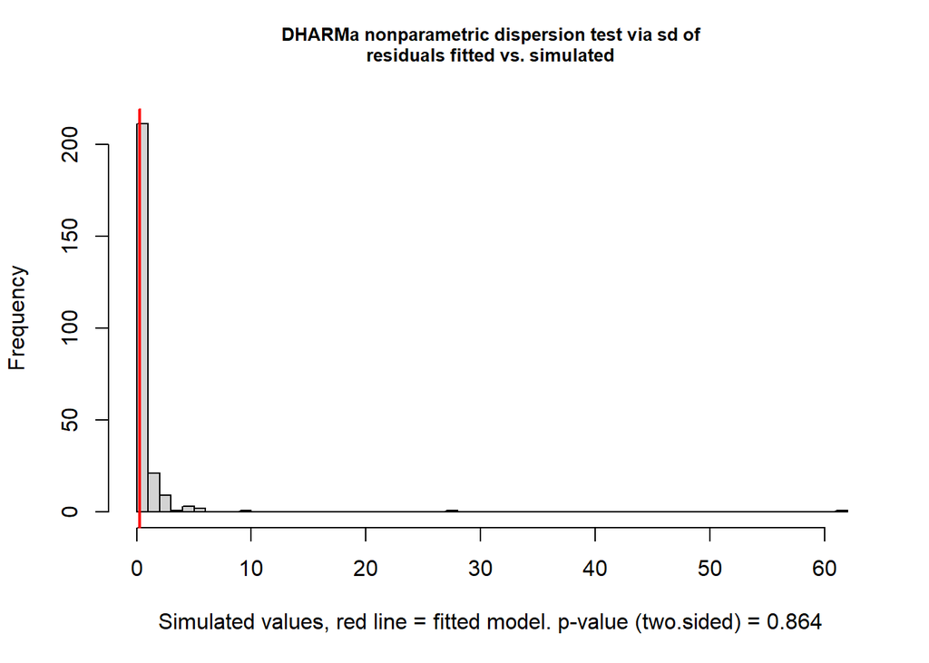

DHARMa nonparametric dispersion test via sd of residuals fitted vs. simulated

data: simulationOutput dispersion = 0.26947, p-value = 0.864 alternative hypothesis: two.sided

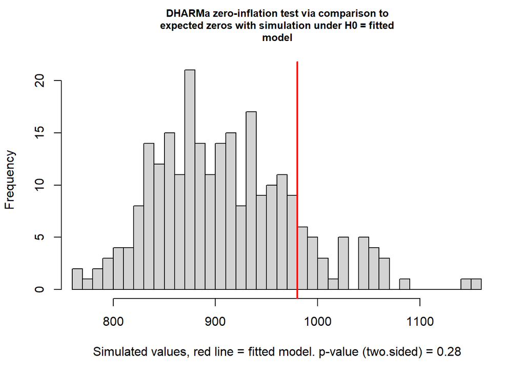

DHARMa zero-inflation test via comparison to expected zeros with simulation under H0 = fitted model

data: simulationOutput ratioObsSim = 1.0773, p-value = 0.28 alternative hypothesis: two.sided

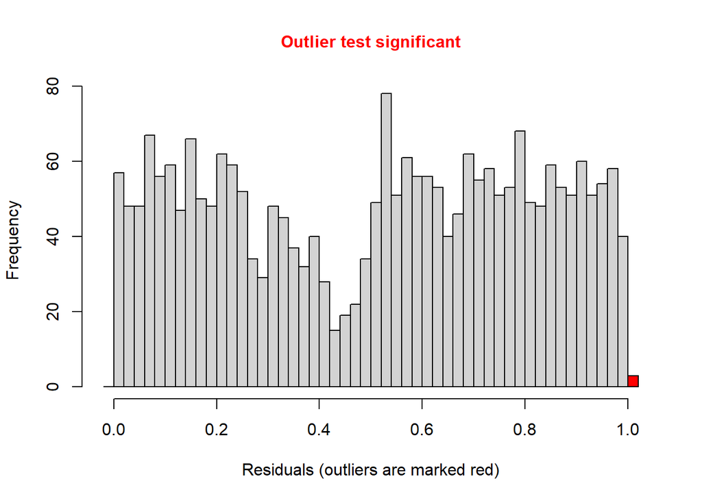

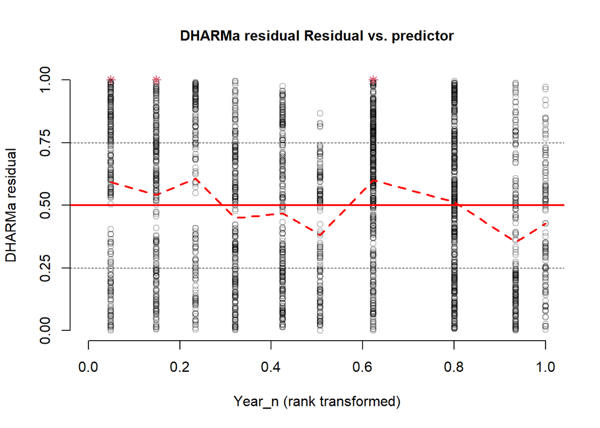

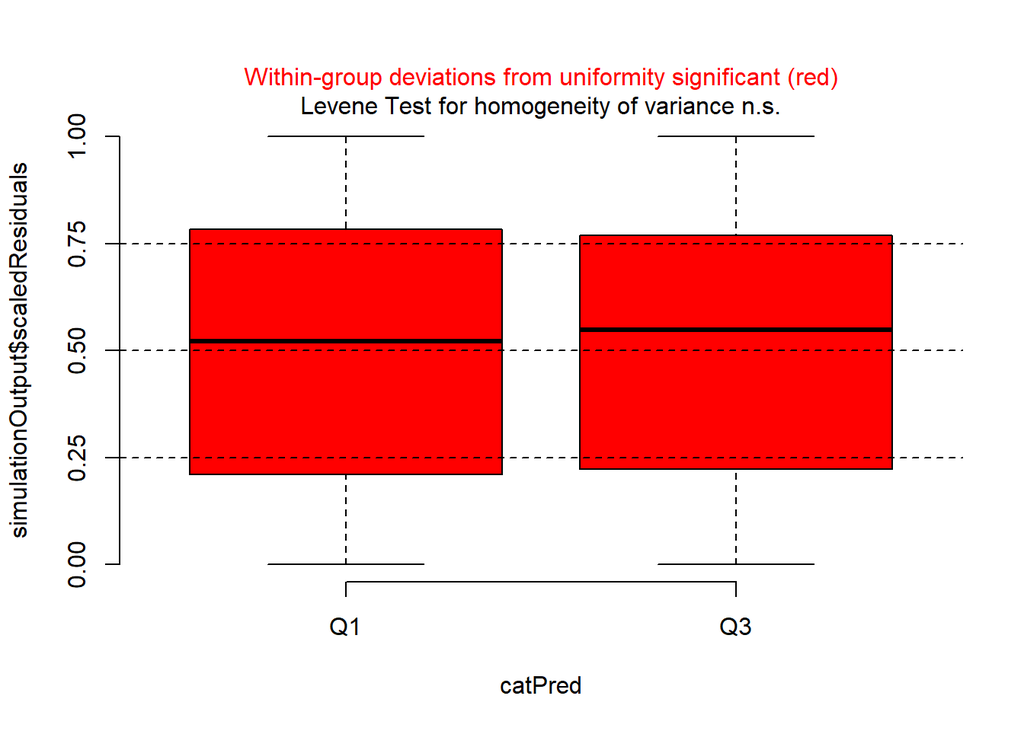

outliers at both margin(s) 10  
Parameter: observations 2465  
p_value: [1] 0.02328368  
Conf int: [1] 0.001947053 0.007447896 attr(,“conf.level”) [1] 0.95

Apalachicola estuary-wide model results

| term | statistic | df | p.value |
| --- | --- | --- | --- |
| Year_c | 6.421 | 1.000 | 0.011 |
| Quarter | 0.786 | 1.000 | 0.375 |

**Model post-hoc:**  
Q: Has oyster abundance changed over time after accounting for Quarter?  
*Estimated marginal means*: Adjusted means accounting for quarter, random effects, and zero-inflation.

Emmeans on response scale:

| 1 | Year_c.trend | SE | df | asymp.LCL | asymp.UCL | annual_pct_change |
| --- | --- | --- | --- | --- | --- | --- |
| overall | 0.035 | 0.014 | Inf | 0.008 | 0.062 | 3.555 |

1 Year_c.trend SE df z.ratio p.value overall 0.0349 0.0138 Inf 2.534 0.0113

Results are averaged over the levels of: Quarter  
There is evidence of an overall increasing temporal trend.

Trend significance

| contrast | ratio | SE | df | null | z.ratio | p.value | Significance |
| --- | --- | --- | --- | --- | --- | --- | --- |
| (Year_c-4.58012170385395) / Year_c4.41987829614605 | 0.730 | 0.091 | Inf | 1.000 | −2.534 | 0.011 | * |

| Year | Year_n | Year_c |
| --- | --- | --- |
| 2015 | 10 | -4.5801217 |
| 2016 | 11 | -3.5801217 |
| 2017 | 12 | -2.5801217 |
| 2018 | 13 | -1.5801217 |
| 2019 | 14 | -0.5801217 |
| 2020 | 15 | 0.4198783 |
| 2021 | 16 | 1.4198783 |
| 2022 | 17 | 2.4198783 |
| 2023 | 18 | 3.4198783 |
| 2024 | 19 | 4.4198783 |

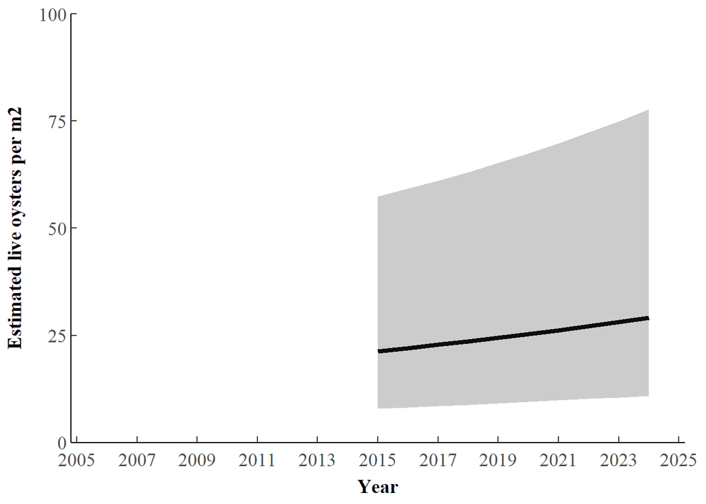

### Sections (linear)

**Background information:**

Average live oyster density

| Year | Mean | SE |
| --- | --- | --- |
| 2015 | 38.96 | 4.72 |
| 2016 | 28.52 | 3.83 |
| 2017 | 56.73 | 6.53 |
| 2018 | 16.30 | 3.35 |
| 2019 | 17.86 | 2.10 |
| 2020 | 4.72 | 0.63 |
| 2021 | 40.12 | 4.31 |
| 2022 | 37.33 | 3.93 |
| 2023 | 16.04 | 3.39 |
| 2024 | 11.30 | 2.69 |

Annual observations per Section

| SectionID | 2015 | 2016 | 2018 | 2019 | 2020 | 2021 | 2022 | 2023 | 2024 | 2017 |
| --- | --- | --- | --- | --- | --- | --- | --- | --- | --- | --- |
| AB.C | 75 | 75 | 75 | 75 | 60 | 150 | 150 | 75 | 30 | 0 |
| AB.E | 85 | 90 | 105 | 95 | 75 | 150 | 150 | 0 | 15 | 90 |
| AB.W | 75 | 80 | 75 | 75 | 15 | 105 | 150 | 120 | 75 | 75 |

Stations per Section

| SectionID | Stations |
| --- | --- |
| AB.C | 5 |
| AB.E | 6 |
| AB.W | 5 |

Observations per Section

| SectionID | Observations |
| --- | --- |
| AB.C | 765 |
| AB.E | 855 |
| AB.W | 845 |

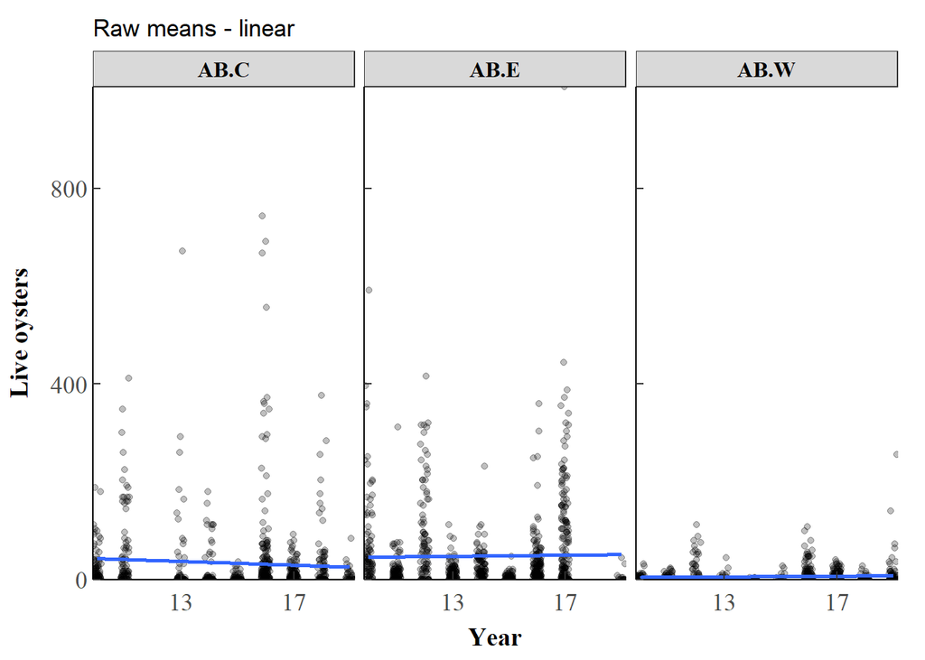

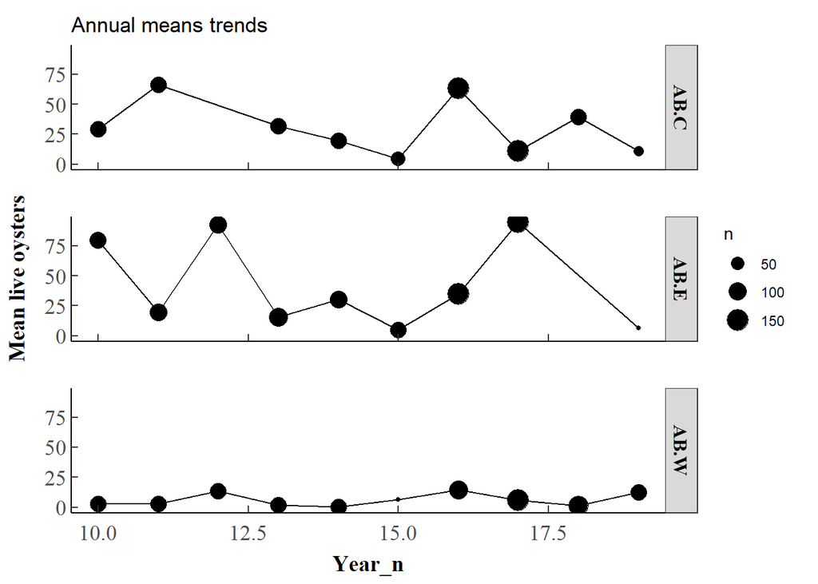

Amount of 0s

| SectionID | n | zeros | zero_pct | mean |
| --- | --- | --- | --- | --- |
| AB.C | 765.00 | 271.00 | 35.42 | 33.64 |
| AB.E | 855.00 | 161.00 | 18.83 | 48.26 |
| AB.W | 845.00 | 548.00 | 64.85 | 6.25 |

**Analyses:**  
Fixed effects - Section  
Random effects - Station (sampling unit)  
Year = continuous to identify trend. Centered to interpret trend at middle timepoint of surveys.  
*Do estuary Sections differ?*

Standard vs 0-inflated

|  | df | AIC |
| --- | --- | --- |
| ABm1 | 7 | 17068.24 |
| ABm2 | 11 | 16720.48 |

Do Sections have different trends?

|  | Df | AIC | BIC | logLik | deviance | Chisq | Chi Df | Pr(>Chisq) |
| --- | --- | --- | --- | --- | --- | --- | --- | --- |
| ABm2 | 11 | 16720.48 | 16784.39 | -8349.242 | 16698.48 | NA | NA | NA |
| ABm3 | 13 | 16709.28 | 16784.80 | -8341.638 | 16683.28 | 15.20771 | 2 | 0.0004985266 |

Linear vs Spline (df=3) trend?

|  | df | AIC |
| --- | --- | --- |
| ABm3 | 13 | 16709.28 |
| ABm4 | 19 | 16653.66 |

Are splines better?

|  | Df | AIC | BIC | logLik | deviance | Chisq | Chi Df | Pr(>Chisq) |
| --- | --- | --- | --- | --- | --- | --- | --- | --- |
| ABm3 | 13 | 16709.28 | 16784.80 | -8341.638 | 16683.28 | NA | NA | NA |
| ABm4 | 19 | 16653.66 | 16764.05 | -8307.829 | 16615.66 | 67.61859 | 6 | 1.257562e-12 |

**Linear model assessment:**  
Residuals:

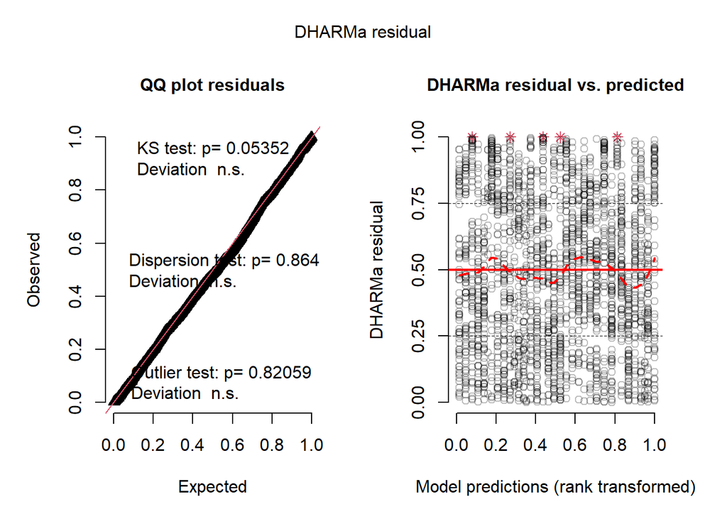

Overdispersion:  
Dispersion ratio > 1 → overdispersion  
Dispersion ratio < 1 → underdispersion

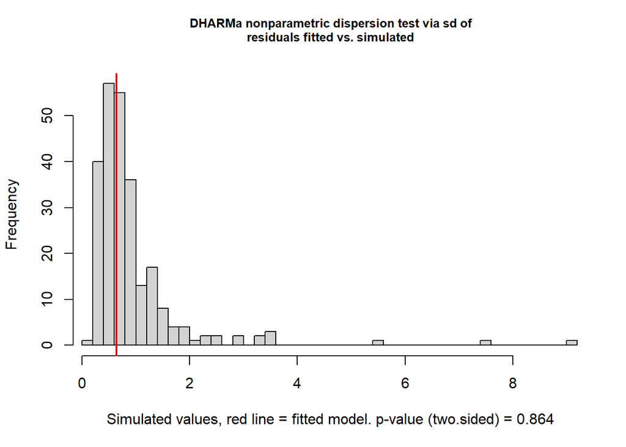

DHARMa nonparametric dispersion test via sd of residuals fitted vs. simulated